# Exploratory_analysis_property_price

Due to the quite large number of zipcodes, let's choose randomly 3 of them and check the relationship between price and living area.

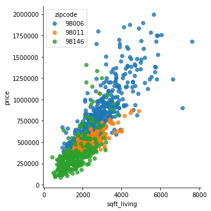

```python
# randomly chosen zipcodes are 98006, 98146, 98011
df_zipcode = df.query("zipcode == [98006, 98146, 98011 ]")
plt.figure(figsize = [10,10]);
sb.lmplot( data = df_zipcode, x = 'sqft_living', y= 'price', hue='zipcode', fit_reg=False, legend=True, legend_out=False);
```

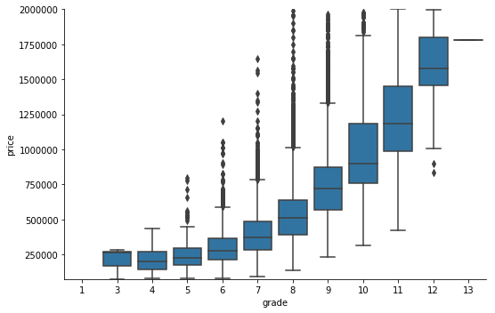

```python
def boxgrid(x, y, **kwargs):
    """ Quick hack for creating box plots with seaborn's PairGrid. """
    default_color = sb.color_palette()[0]
    sb.boxplot(x, y, color = default_color)

plt.figure(figsize = [10, 10])
g = sb.PairGrid(data = df, y_vars = ['price'], x_vars = ['grade'],
                size = 5, aspect = 1.5);
g.map(boxgrid)
plt.ylim(df.price.min(), df.price.max())
plt.show();
```

```python
df.head()
```

|  | id | date | price | bedrooms | bathrooms | sqft_living | sqft_lot | floors | waterfront | view | ... | zipcode | lat | long | sqft_living15 | sqft_lot15 | sqft_diffence | grade_int | month_year | yr_built_range | yr_renovated_range |
| --- | --- | --- | --- | --- | --- | --- | --- | --- | --- | --- | --- | --- | --- | --- | --- | --- | --- | --- | --- | --- | --- |
| 0 | 7129300520 | 2014-10-13 | 221900.0 | 3 | 1.00 | 1180 | 5650 | 1.0 | 0 | 0 | ... | 98178 | 47.5112 | -122.257 | 1340 | 5650 | 0 | 7 | Oct 2014 | (1950, 1955] | NaN |
| 1 | 6414100192 | 2014-12-09 | 538000.0 | 3 | 2.25 | 2570 | 7242 | 2.0 | 0 | 0 | ... | 98125 | 47.7210 | -122.319 | 1690 | 7639 | 400 | 7 | Dec 2014 | (1950, 1955] | (1990, 1995] |
| 2 | 5631500400 | 2015-02-25 | 180000.0 | 2 | 1.00 | 770 | 10000 | 1.0 | 0 | 0 | ... | 98028 | 47.7379 | -122.233 | 2720 | 8062 | 0 | 6 | Feb 2015 | NaN | NaN |
| 3 | 2487200875 | 2014-12-09 | 604000.0 | 4 | 3.00 | 1960 | 5000 | 1.0 | 0 | 0 | ... | 98136 | 47.5208 | -122.393 | 1360 | 5000 | 910 | 7 | Dec 2014 | (1960, 1965] | NaN |
| 4 | 1954400510 | 2015-02-18 | 510000.0 | 3 | 2.00 | 1680 | 8080 | 1.0 | 0 | 0 | ... | 98074 | 47.6168 | -122.045 | 1800 | 7503 | 0 | 8 | Feb 2015 | (1985, 1990] | NaN |

5 rows × 26 columns

```python
df_clean = df.query('(grade == 5 & price < 480000) | (grade == 6 & price < 600000) | (grade == 7 & price < 780000) | (grade == 8 & price < 950000) | (grade == 7 & price < 780000) | (grade == 8 & price < 950000) | (grade == 9 & price < 1300000) | (grade == 10 & price < 1800000) | (grade == 12 & price > 90000) | (grade == [3,4,11]) ')
```

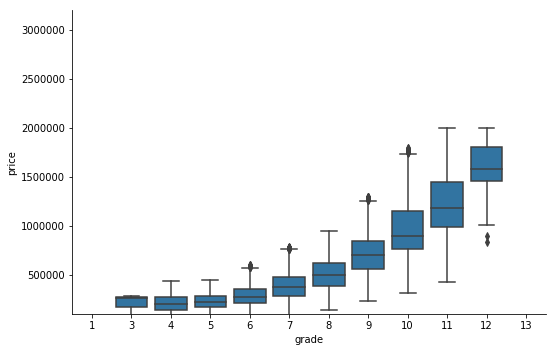

```python
def boxgrid(x, y, **kwargs):
    """ Quick hack for creating box plots with seaborn's PairGrid. """
    default_color = sb.color_palette()[0]
    sb.boxplot(x, y, color = default_color)


plt.figure(figsize = [10, 10])
g = sb.PairGrid(data = df_clean, y_vars = ['price'], x_vars = ['grade'],
                size = 5, aspect = 1.5);
g.map(boxgrid)
plt.ylim(100000, 3200000)
plt.show();
```

```python
df_clean[['c1','c2','c3','c4','c5']] =  pd.get_dummies(df_clean.condition)
```

```python
#prepare dataset for regression
trainingSet, testSet = train_test_split(df_clean, test_size=0.4) #split data on training and testing

trainingSet['grade_int_quad']=trainingSet.grade_int*trainingSet.grade_int
testSet['grade_int_quad']=testSet.grade_int*testSet.grade_int # we need to have the same scolumns to concat later
trainingSet['intercept'] = 1
testSet['intercept'] = 1 # we need to have the same scolumns to concat later

lm=sm.OLS(trainingSet['price'], trainingSet[['intercept', 'sqft_living', 'grade_int_quad', 'grade_int', 'c1','c2','c4','c5' ]])
results =lm.fit()
results.summary()
```

OLS Regression Results

| Dep. Variable: | price | R-squared: | 0.621 |
| --- | --- | --- | --- |
| Model: | OLS | Adj. R-squared: | 0.621 |
| Method: | Least Squares | F-statistic: | 2907. |
| Date: | Thu, 17 Jan 2019 | Prob (F-statistic): | 0.00 |
| Time: | 02:22:19 | Log-Likelihood: | -1.6610e+05 |
| No. Observations: | 12415 | AIC: | 3.322e+05 |
| Df Residuals: | 12407 | BIC: | 3.323e+05 |
| Df Model: | 7 |  |  |
| Covariance Type: | nonrobust |  |  |

|  | coef | std err | t | P>\|t\| | [0.025 | 0.975] |
| --- | --- | --- | --- | --- | --- | --- |
| intercept | 6.852e+05 | 4.51e+04 | 15.194 | 0.000 | 5.97e+05 | 7.74e+05 |
| sqft_living | 86.5381 | 2.519 | 34.351 | 0.000 | 81.600 | 91.476 |
| grade_int_quad | 2.063e+04 | 707.386 | 29.158 | 0.000 | 1.92e+04 | 2.2e+04 |
| grade_int | -2.107e+05 | 1.13e+04 | -18.675 | 0.000 | -2.33e+05 | -1.89e+05 |
| c1 | -3.135e+04 | 4.35e+04 | -0.720 | 0.472 | -1.17e+05 | 5.4e+04 |
| c2 | -2.837e+04 | 1.56e+04 | -1.817 | 0.069 | -5.9e+04 | 2226.785 |
| c4 | 4.104e+04 | 3307.944 | 12.405 | 0.000 | 3.46e+04 | 4.75e+04 |
| c5 | 1.034e+05 | 5519.662 | 18.726 | 0.000 | 9.25e+04 | 1.14e+05 |

| Omnibus: | 1147.026 | Durbin-Watson: | 1.998 |
| --- | --- | --- | --- |
| Prob(Omnibus): | 0.000 | Jarque-Bera (JB): | 2153.744 |
| Skew: | 0.632 | Prob(JB): | 0.00 |
| Kurtosis: | 4.601 | Cond. No. | 7.38e+04 |

Warnings:  
[1] Standard Errors assume that the covariance matrix of the errors is correctly specified.  
[2] The condition number is large, 7.38e+04. This might indicate that there are  
strong multicollinearity or other numerical problems.

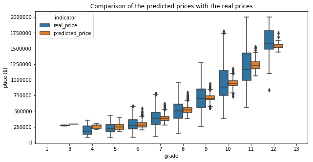

```python
testSet['indicator'] = 'predicted_price'
trainingSet['indicator'] = 'real_price'


#calculate the predictected prices
testSet.price =  testSet.grade_int_quad*2.063e+04 + testSet.grade_int*(-2.114e+05)+testSet.sqft_living*88.0900+testSet.c1*(-5502.8174) + testSet.c2*(-2.23e+04)+testSet.c4*(4.103e+04)+testSet.c5*(1.04e+05) + 6.857e+05

#concat training and testing datasets
df_train_test_sets = pd.concat([trainingSet, testSet])



default_color = sb.color_palette()[0]
plt.figure(figsize = [10, 5])
sb.boxplot(x=df_train_test_sets['grade'], y=df_train_test_sets['price'], hue = df_train_test_sets.indicator );
plt.title('Comparison of the predicted prices with the real prices');
plt.ylabel('ptice ($)');
```

We can see that the obtained regresion model fits the real data quite well. The parabolic approximation was used for the predictor variable grade . Dummy variables were also introduced for condition variable.

## Conclustion on multivariant exploration

- From violin plot we could see for differen condition the relationship that the higher grade the higher prices
- During a year average prices do not evolve much. For lower grade- 5, we do not see dependence on condition. However, for higher grade we can see that with the higher rated condition the price is higher.
- Depending on the built year we can see that the average prices decreases for older properties. Again, we can see a tendancy that higher rated condtions correspond to higher prices. In addition, one can notice an uptrend for the prices.
- The later was renovation the higer property prices. Again we could see the condition based dependance.
- Waterfront also skyrocket prices. The prices with waterfront are amonge the highest prices on properties.
- Prices also depend on the zipcode
- A quadratic regression model was created and it fits quite well.

```python
# save obtained datasets:

df.to_csv('df.csv', sep=',')
df_train_test_sets.to_csv('df_train_test_sets.csv', sep=',')
```